# 第1章 回帰モデルとスパース推定

Osamu, MORIMOTO

2023-10-12

## 正則化回帰は真の偏回帰係数を推定できるのか？

そもそもの話として、正則化回帰は真の偏回帰係数を推定できているのか？という点について人工データで実験してみる。

最小二乗法による線形回帰では不偏推定量が得られるが、正則化項を付けると不偏性が失われるので予測モデルとしては使えても、真の偏回帰係数を推定できないはず。

以下の2パターンで考える。

- 素直なデータ。説明変数5個、n=50。
- 説明変数が多くてサンプルサイズが少ないデータ。説明変数101個、n=102。

- 線形回帰
- Ridge回帰
- LASSO回帰
- 適応的LASSO回帰
- エラスティックネット
- LASSOで変数選択したのち線形回帰
- 適応的LASSO回帰で変数選択したのち線形回帰

## 準備

準備として各種パッケージの読み込みと必要な関数の定義を行う。

```r
if (!require("pacman")) {
  install.packages("pacman")
} # パッケージ管理
pacman::p_load(conflicted, tidyverse, glmnetUtils)
```

Ridge回帰とLASSO回帰の適切なλを情報量規準AICcで選択する関数。

```r
AICc_glmnet <- function(glmnet_model) {
  tLL <- glmnet_model$nulldev - deviance(glmnet_model)
  k <- glmnet_model$df
  n <- glmnet_model$nobs
  df <- tibble(
    lambda = glmnet_model$lambda,
    AICc = -tLL + 2 * k + 2 * k * (k + 1) / (n - k - 1)
  )
  best_AICc_lambda <- df |>
    slice_min(AICc) |>
    pull(lambda)
  return(
    list(
      best_AICc_lambda = best_AICc_lambda,
      AICc = df$AICc
    )
  )
}
```

エラスティックネットのαとλを情報量規準AICcで選択する関数

```r
get_ic_best_alpha_lambda <- function(cva_model) {
  n <- cva_model$alpha |>
    length()

  ics <- map(
    1:n,
    \(list_no) cva_model |>
      pluck("modlist", list_no, "glmnet.fit") |>
      AICc_glmnet()
  )
  df_ic <- map(
    1:n,
    \(list_no) data.frame(
      best_alpah = cva_model |> pluck("alpha", list_no),
      best_lambda = cva_model |> pluck("modlist", list_no, "lambda"),
      AICc = ics |> pluck(list_no, "AICc")
    )
  ) |>
    list_rbind()
  df_ic_best <- list(
    AICc_best_alpha = df_ic |> slice_min(AICc) |> pull(best_alpah),
    AICc_best_lambda = df_ic |> slice_min(AICc) |> pull(best_lambda)
  )

  return(df_ic_best)
}
```

そして、シミュレーションを行う関数。

指定の人工データを生成し、各モデルの偏回帰係数を出力する。

```r
# sim_f(N, K, seed)
# N: サンプルサイズ
# K: 変数の数
# seed: 再現のための乱数種
sim_f <- function(N, K, seed) {
  set.seed(seed)

  X <- MASS::mvrnorm(N, mu = rep(0, K), Sigma = diag(K))

  Y <- X %*% beta + rnorm(N)

  df <- X |>
    as.data.frame() |>
    bind_cols(data.frame(Y = Y))

  # lm
  coef_lm <- lm(Y ~ ., data = df) |>
    broom::tidy() |>
    slice(-1) |>
    select(term, estimate)

  # Ridge
  ridge_best_lambda <- glmnet(Y ~ ., data = df, alpha = 0) |> AICc_glmnet()

  coef_ridge <- glmnet(Y ~ ., data = df, alpha = 0, lambda = ridge_best_lambda$best_AICc_lambda) |>
    broom::tidy() |>
    slice(-1) |>
    select(term, estimate)

  # LASSO
  lasso_best_lambda <- glmnet(Y ~ ., data = df, alpha = 1) |> AICc_glmnet()

  coef_lasso <- glmnet(Y ~ ., data = df, alpha = 1, lambda = lasso_best_lambda$best_AICc_lambda) |>
    broom::tidy() |>
    slice(-1) |>
    select(term, estimate)

  # 適応的LASSO
  coef_alasso <- glmnet(Y ~ .,
    data = df, alpha = 1,
    lambda = 5 / nrow(df)^(3 / 4),
    penalty.factor = 1 / abs(coef_lm$estimate)
  ) |>
    broom::tidy() |>
    slice(-1) |>
    select(term, estimate)

  # EN
  EN_best_alpha_lambda <- cva.glmnet(Y ~ ., data = df) |>
    get_ic_best_alpha_lambda()

  coef_EN <- glmnet(Y ~ .,
    data = df,
    alpha = EN_best_alpha_lambda$AICc_best_alpha,
    lambda = EN_best_alpha_lambda$AICc_best_lambda
  ) |>
    broom::tidy() |>
    slice(-1) |>
    select(term, estimate)

  # LASSOの変数選択に基づく線形回帰
  coef_lasso2lm <- lm(
    Y ~ .,
    data = df |>
      select(!Y) |>
      rowid_to_column() |>
      pivot_longer(!rowid) |>
      inner_join(coef_lasso, by = join_by(name == term)) |>
      select(!estimate) |>
      pivot_wider(names_from = name, values_from = value) |>
      select(!rowid) |>
      mutate(Y = df$Y)
  ) |>
    broom::tidy() |>
    slice(-1) |>
    select(term, estimate)

  # 適応的LASSOの変数選択に基づく線形回帰
  coef_alasso2lm <- lm(
    Y ~ .,
    data = df |>
      select(!Y) |>
      rowid_to_column() |>
      pivot_longer(!rowid) |>
      inner_join(coef_alasso, by = join_by(name == term)) |>
      select(!estimate) |>
      pivot_wider(names_from = name, values_from = value) |>
      select(!rowid) |>
      mutate(Y = df$Y)
  ) |>
    broom::tidy() |>
    slice(-1) |>
    select(term, estimate)

  # res
  res <- coef_lm |>
    left_join(coef_ridge, by = join_by(term)) |>
    left_join(coef_lasso, by = join_by(term)) |>
    left_join(coef_alasso, by = join_by(term)) |>
    left_join(coef_EN, by = join_by(term)) |>
    left_join(coef_lasso2lm, by = join_by(term)) |>
    left_join(coef_alasso2lm, by = join_by(term)) |>
    rename(
      線形回帰 = estimate.x,
      Ridge回帰 = estimate.y,
      LASSO回帰 = estimate.x.x,
      適応的LASSO回帰 = estimate.y.y,
      エラスティックネット = estimate.x.x.x,
      `LASSO->線形回帰` = estimate.y.y.y,
      `適応的LASSO->線形回帰` = estimate
    )

  return(res)
}
```

## 素直なデータ

まずは素直なデータ。 説明変数5個、サンプルサイズ50。

試行回数300回。

- 線形回帰は真の偏回帰係数を中心に分布していて、バラツキも小さい。
- 正則化回帰はいずれも過小推定の傾向がある。
- しかし、LASSOで変数選択→線形回帰は意外と悪くない結果。

```r
K <- 5 # 説明変数の数

N <- 50 # サンプルサイズ

I <- 300 # 試行回数

beta <- seq(-1, 1, length.out = K)

res <- map(
  1:I,
  \(seed) sim_f(N, K, seed) #,  .progress = TRUE
  ) |>
  list_rbind() |>
  pivot_longer(!term) |>
  mutate(
    value = replace_na(value, 0),
    name = factor(
      name,
      levels = c(
        "線形回帰", "Ridge回帰", "LASSO回帰", "適応的LASSO回帰",
        "エラスティックネット", "LASSO->線形回帰", "適応的LASSO->線形回帰"
      )
    )
  )
```

推定された偏回帰係数の分布。

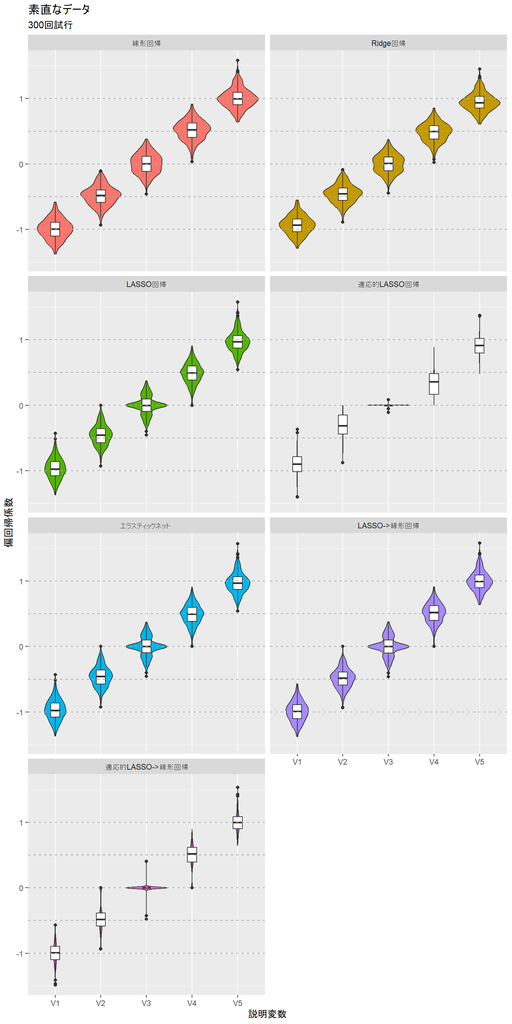

```r
res |>
  ggplot(aes(x = term, y = value, fill = name)) +
  geom_violin() +
  geom_boxplot(fill = "white", width = 0.2) +
  geom_hline(yintercept = beta, linetype = 2, color = "darkgray") +
  facet_wrap(vars(name), ncol = 2) +
  theme(legend.position = "none") +
  labs(x = "説明変数", y = "偏回帰係数", title = "素直なデータ", subtitle = "300回試行")
```

各モデルの偏回帰係数の平均値。

```r
res |>
  summarise(across(everything(), mean), .by = c(term, name)) |>
  mutate(value = round(value, 3)) |>
  pivot_wider(names_from = name, values_from = value) |>
  mutate(真の値 = c(-1, -0.5, 0, 0.5, 1), .before = 2)
```

| term | 真の値 | 線形回帰 | Ridge回帰 | LASSO回帰 | 適応的LASSO回帰 | エラスティックネット | LASSO->線形回帰 | 適応的LASSO->線形回帰 |
| --- | --- | --- | --- | --- | --- | --- | --- | --- |
| V1 | -1.0 | -0.996 | -0.936 | -0.965 | -0.903 | -0.964 | -0.994 | -0.994 |
| V2 | -0.5 | -0.486 | -0.457 | -0.455 | -0.299 | -0.456 | -0.484 | -0.448 |
| V3 | 0.0 | 0.002 | 0.003 | 0.002 | 0.000 | 0.002 | 0.002 | -0.002 |
| V4 | 0.5 | 0.515 | 0.484 | 0.485 | 0.335 | 0.486 | 0.512 | 0.487 |
| V5 | 1.0 | 1.005 | 0.945 | 0.976 | 0.912 | 0.975 | 1.004 | 1.004 |

## サンプルサイズが少ないケース

説明変数の数が多く、サンプルサイズが少ないケース。

ただし、サンプルサイズが説明変数の数より小さくなると線形回帰の解が出ないので、サンプルサイズを説明変数の数＋１にしている。

説明変数101個、サンプルサイズ102個。

真の偏回帰係数が、それぞれ真の偏回帰係数が-1, -0.5, 0, 0.5, 1である説明変数について推定値を確認する。

- 線形回帰はとにかくバラツキが大きく、平均値で見ても真の値から大きく外れている。
- Ridgeは安定しているがほとんどゼロに近く過小推定。
- LASSO, エラスティックネットも安定しているが過小評価の傾向にある。
- 適応的LASSOが比較的ましだがやはり過小評価の傾向にはある。
- 意外なことに、適応的LASSO→線形回帰がかなり真の値に近い。
- いずれにしても、それぞれの偏回帰係数を影響力の大きさとして解釈するのは注意が必要。

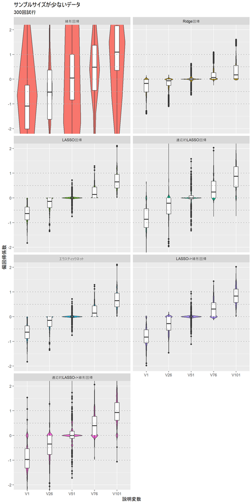

```r
K <- 101 # 説明変数の数

N <- 102 # サンプルサイズ

I <- 300 # 300 # 試行回数

beta <- seq(-1, 1, length.out = K)

res <- map(
  1:I,
  \(seed) sim_f(N, K, seed) #, .progress = TRUE
) |>
  list_rbind() |>
  pivot_longer(!term) |>
  mutate(
    value = replace_na(value, 0),
    name = factor(
      name,
      levels = c(
        "線形回帰", "Ridge回帰", "LASSO回帰", "適応的LASSO回帰",
        "エラスティックネット", "LASSO->線形回帰", "適応的LASSO->線形回帰"
      )
    )
  )

res |>
  dplyr::filter(term %in% c("V1", "V26", "V51", "V76", "V101")) |>
  mutate(term = factor(term, levels = c("V1", "V26", "V51", "V76", "V101"))) |>
  ggplot(aes(x = term, y = value, fill = name)) +
  geom_violin() +
  geom_boxplot(fill = "white", width = 0.2) +
  geom_hline(yintercept = c(-1, -0.5, 0, 0.5, 1.0), linetype = 2, color = "darkgray") +
  facet_wrap(vars(name), ncol = 2) +
  theme(legend.position = "none") +
  coord_cartesian(ylim = c(-2, 2)) +
  labs(x = "説明変数", y = "偏回帰係数", title = "サンプルサイズが少ないデータ", subtitle = "300回試行")
```

各モデルの偏回帰係数の平均値。

```r
res |>
  dplyr::filter(term %in% c("V1", "V26", "V51", "V76", "V101")) |>
  mutate(term = factor(term, levels = c("V1", "V26", "V51", "V76", "V101"))) |>
  summarise(across(everything(), mean), .by = c(term, name)) |>
  mutate(value = round(value, 2)) |>
  pivot_wider(names_from = name, values_from = value) |>
  mutate(真の値 = c(-1, -0.5, 0, 0.5, 1), .before = 2)
```

| term | 真の値 | 線形回帰 | Ridge回帰 | LASSO回帰 | 適応的LASSO回帰 | エラスティックネット | LASSO->線形回帰 | 適応的LASSO->線形回帰 |
| --- | --- | --- | --- | --- | --- | --- | --- | --- |
| V1 | -1.0 | 3.94 | -0.29 | -0.63 | -0.84 | -0.63 | -0.79 | -0.92 |
| V26 | -0.5 | -0.46 | -0.15 | -0.23 | -0.37 | -0.23 | -0.32 | -0.42 |
| V51 | 0.0 | -5.44 | 0.00 | -0.01 | 0.01 | -0.01 | -0.02 | 0.01 |
| V76 | 0.5 | 1.02 | 0.15 | 0.25 | 0.37 | 0.25 | 0.33 | 0.44 |
| V101 | 1.0 | 0.48 | 0.31 | 0.68 | 0.86 | 0.68 | 0.84 | 0.95 |

TOPへ戻る